# Tarea 8 - Pruebas de Hipótesis

Héctor Hibran Tapia Fernández - A01661114

2024-08-23

## Enlatados

Los pesos de 21 latas de duraznos empacados elegidas al azar fueron:

Peso de las latas: 11, 11.6, 11.6, 11.7, 10.9, 11.6, 12, 11.2, 11.5, 12, 12, 11.4, 11.2, 10.8, 10.5, 11.8, 12.2, 10.9, 11.8, 11.4, 12.1

Por estudios anteriores se saber que población del peso de las latas se distribuye normalmente.

Si a los dueños no les conviene que el peso sea menor, pero tampoco mayor a 11.7, prueba la afirmación de que el verdadero peso de las latas es de 11.7 con un nivel de confianza de 0.98 haciendo uso de los datos obtenidos en la muestra.

### Muestra tu procedimiento siguiendo los 4 pasos de las pruebas de hipótesis.

**Paso 1. Hipótesis (De dos colas)**

- $H_0: \mu = 11.7$
- $H_1: \mu \neq 11.7$

¿Cómo se distribuye $\bar{x}$?

- X se distribuye como una Normal
- n < 30
- No conocemos sigma

Entonces usaremos la Prueba t de Student.

**Paso 2. Regla de Decisión**

Nivel de confianza es de 0.98 Nivel de significancía es de 0.02

Necesito encontrar a cuántas desviaciones estándar está lejos el valor frontera.

```r
n = 21
alfa = 0.02
t_f = qt(alfa/2, n-1)
cat("t_f = ", t_f)
```

```
## t_f =  -2.527977
```

Rechazo $H_0$ sí:

- $|t_e| > 2.53$
- $p\text{-valor} < 0.02$

**Paso 3. Análisis del Resultado**

- $t_e$: Número de desviaciones al que $\bar{x}$ se encuentra lejos de $mu = 11.7$
- Valor P: Proababilidad de obtener lo que obtuve de muestra o un valor más extremo.

*Estadístico de Prueba*

```r
X = c(11, 11.6, 11.6, 11.7, 10.9, 11.6, 12, 11.2, 11.5, 12, 12, 11.4, 11.2, 10.8, 10.5, 11.8, 12.2, 10.9, 11.8, 11.4, 12.1)

xb = mean(X)
s = sd(X)
mu = 11.7

te = (xb - mu) / (s/sqrt(n))
cat("te =", te, "\n")
```

```
## te = -2.068884
```

```r
valorp = 2*pt(te, n-1)
cat("Valor p =", valorp)
```

```
## Valor p = 0.0517299
```

**Un atajo**

```r
t.test(X, mu = 11.7, alternative = ("two.sided"), conf.level = 0.98)
```

```
##
##  One Sample t-test
##
## data:  X
## t = -2.0689, df = 20, p-value = 0.05173
## alternative hypothesis: true mean is not equal to 11.7
## 98 percent confidence interval:
##  11.22388 11.74755
## sample estimates:
## mean of x
##  11.48571
```

**Paso 4. Conclusión**

Comparamos: Regla de Decisión vs Análisis de Resultado.

*$|t_e| = 2.07 < 2.53$ -> No se rechaza la $H_0$* $p\text{-valor} = 0.05 > 0.02$ -> No se rechaza la $H_0$

### Elabora un gráfico que muestre la regla de decisión y el punto donde queda el estadístico de prueba.

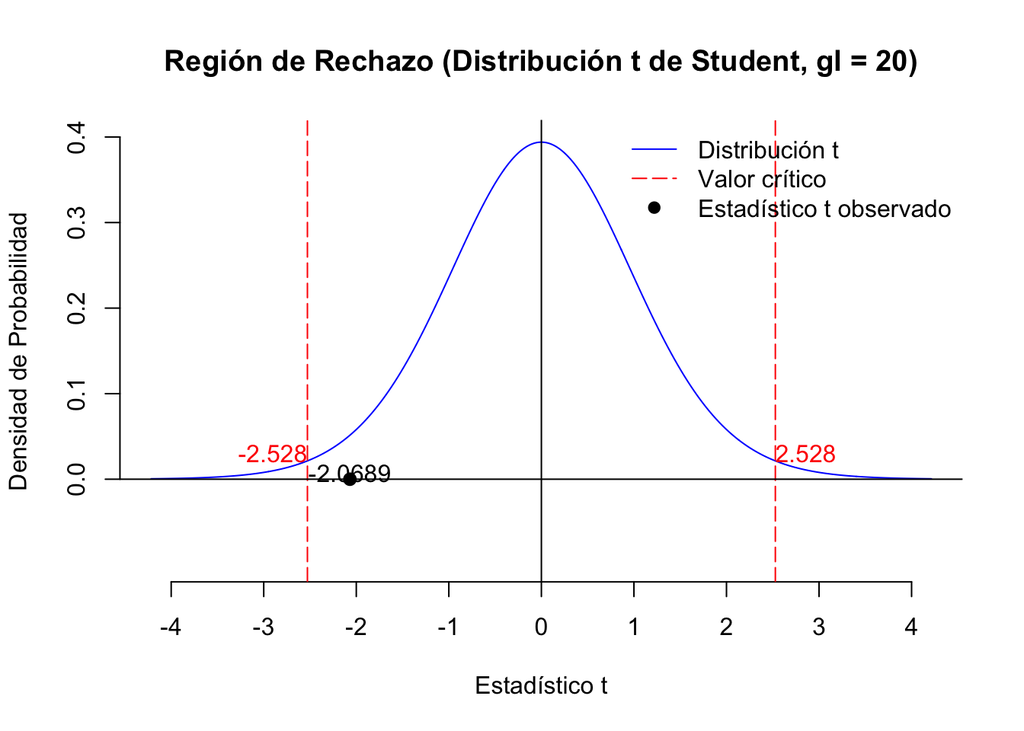

```r
n <- 21  # tamaño de la muestra
gl <- n - 1  # grados de libertad

sigma <- sqrt((n - 1) / (n - 3)) # Factor de ajuste para la distribución t
x <- seq(-4 * sigma, 4 * sigma, 0.01) # Valores para el eje x
y <- dt(x, gl) # Densidad de la distribución t con gl grados de libertad
alpha <- 0.02 # Estadístico t crítico para la región de rechazo a un nivel de confianza del 98%

t_f <- qt(1 - alpha / 2, gl)  # Valor crítico de t para dos colas
te <- -2.0689  # Este es el valor del estadístico t obtenido del test

plot(x, y, type = "l", col = "blue", xlab = "Estadístico t", ylab = "Densidad de Probabilidad",
     ylim = c(-0.1, 0.4), frame.plot = FALSE, xaxt = "n", yaxt = "n",
     main = "Región de Rechazo (Distribución t de Student, gl = 20)")

axis(1, at = seq(-4, 4, by = 1))
axis(2, at = seq(0, 0.4, by = 0.1))

abline(v = t_f, col = "red", lty = 5)
abline(v = -t_f, col = "red", lty = 5)

text(t_f, 0.03, paste0(round(t_f, 3)), col = "red", adj = 0)
text(-t_f, 0.03, paste0(round(-t_f, 3)), col = "red", adj = 1)

abline(h = 0)
abline(v = 0, col = "black")

points(te, 0, pch = 19, cex = 1.1)
text(te, -0.02, "-2.0689", pos = 3)

legend("topright", legend = c("Distribución t", "Valor crítico", "Estadístico t observado"),
       col = c("blue", "red", "black"), lty = c(1, 5, NA), pch = c(NA, NA, 19), bty = "n")
```

### Concluye en el contexto del problema.

- El valor del estadístico de prueba t es -2.069, que está dentro del rango de no rechazo de la hipótesis nula, ya que $|-2.069∣ < 2.528$, lo que significa que no rechazamos la hipótesis nula. Con un nivel de confianza del 98%, no hay suficiente evidencia para concluir que el verdadero peso promedio de las latas sea diferente de 11.7.

## La decisión de Fowle Marketing Research, Inc.

Fowle Marketing Research, Inc., basa los cargos a un cliente bajo el supuesto de que las encuestas telefónicas (para recopilación de datos) pueden completarse en un tiempo medio de 15 minutos o menos. Si el tiempo es mayor a 15 minutos entonces se cobra una tarifa adicional. Compañías que contratan estos servicios piensan que el tiempo promedio es mayor a lo que especifica Fowle Marketing Research Inc. así que realizan su propio estudio en una muestra aleatoria de llamadas telefónicas y encuentran los siguientes datos:

Tiempo: 17, 11, 12, 23, 20, 23, 15, 16, 23, 22, 18, 23, 25, 14, 12, 12, 20, 18, 12, 19, 11, 11, 20, 21, 11, 18, 14, 13, 13, 19, 16, 10, 22, 18, 23

Por experiencias anteriores, se sabe que σ=4 minutos. Usando un nivel de significancia de 0.07, ¿está justificada la tarifa adicional?

### Muestra tu procedimiento siguiendo los 4 pasos de las pruebas de hipótesis.

**Paso 1. Hipótesis (De una cola)**

- $H_0: \mu \leq 15$
- $H_1: \mu > 15$

¿Cómo se distribuye $\bar{x}$?

- X se distribuye como una Normal
- n > 30
- Conocemos sigma

Entonces usaremos la Prueba Z.

**Paso 2. Regla de Decisión**

Nivel de confianza es de 0.93 Nivel de significancia es de 0.07

**Ya sabemos que la desviación estándar de la población (sigma) es igual a 4.**

Para α = 0.07 podemos, buscar el valor crítico z correspondiente a un test de una cola, usando tablas de la distribución normal estándar, o lo siguiente:

```r
alfa = 0.07
z_critico = qnorm(1 - alfa)
cat("z_critico = ", z_critico)
```

```
## z_critico =  1.475791
```

Rechazo $H_0$ sí:

- $z > 1.48$
- $p\text{-valor} < 0.07$

**Paso 3. Análisis del Resultado**

- $z$: Indica cuántas desviaciones estándar está la media muestral por encima de la media poblacional supuesta bajo la hipótesis nula (μ = 15 minutos).
- Valor P: Proababilidad de obtener lo que obtuve de muestra o un valor más extremo.

*Estadístico de Prueba*

```r
X = c(17, 11, 12, 23, 20, 23, 15, 16, 23, 22, 18, 23, 25, 14, 12, 12, 20, 18, 12, 19, 11, 11, 20, 21, 11, 18, 14, 13, 13, 19, 16, 10, 22, 18, 23)

n = length(X)
xb = mean(X)
mu = 15
sigma = 4

z = (xb - mu) / (sigma / sqrt(n))
cat("Estadístico de Prueba Z =", z)
```

```
## Estadístico de Prueba Z = 2.95804
```

```r
p_value = 1 - pnorm(z)
cat("Valor p =", p_value, "\n")
```

```
## Valor p = 0.00154801
```

**Un atajo**

```r
library(BSDA)
sigma = 4
z_test_result = z.test(X, mu = 15, sigma.x = sigma, alternative = "greater")
z_test_result
```

```
##
##  One-sample z-Test
##
## data:  X
## z = 2.958, p-value = 0.001548
## alternative hypothesis: true mean is greater than 15
## 95 percent confidence interval:
##  15.88788       NA
## sample estimates:
## mean of x
##        17
```

**Paso 4. Conclusión**

Comparamos: Regla de Decisión vs Análisis de Resultado.

- $z = 2.958 > 1.48$ -> Se rechaza la $H_0$
- $p\text{-valor} = 0.001548 < 0.07$ -> Se rechaza la $H_0$

### Elabora un gráfico que muestre la regla de decisión y el punto donde queda el estadístico de prueba.

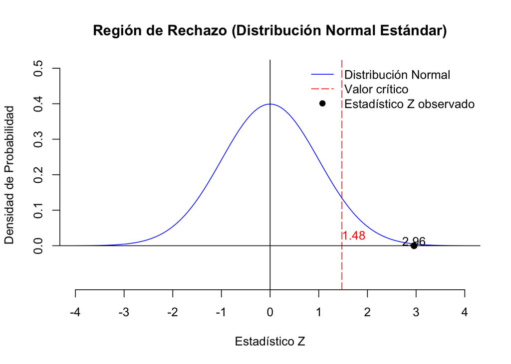

```r
mu <- 15  # Media poblacional bajo la hipótesis nula
sigma <- 4  # Desviación estándar de la población
n = length(X) # Tamaño de la muestra
alpha <- 0.07  # Nivel de significación
z_observado <- 2.95804  # Estadístico Z observado
z_critico <- qnorm(1 - alpha)  # Valor crítico de Z para una cola

x <- seq(-4, 4, 0.01)
y <- dnorm(x)

plot(x, y, type = "l", col = "blue", xlab = "Estadístico Z", ylab = "Densidad de Probabilidad",
     ylim = c(-0.1, 0.5), frame.plot = FALSE, xaxt = "n", yaxt = "n",
     main = "Región de Rechazo (Distribución Normal Estándar)")

axis(1, at = seq(-4, 4, by = 1))
axis(2, at = seq(0, 0.5, by = 0.1))

abline(v = z_critico, col = "red", lty = 5)
text(z_critico, 0.03, paste0(round(z_critico, 2)), col = "red", adj = 0)

abline(h = 0)
abline(v = 0, col = "black")

points(z_observado, 0, pch = 19, cex = 1.1)
text(z_observado, -0.02, round(z_observado, 2), pos = 3)

legend("topright", legend = c("Distribución Normal", "Valor crítico", "Estadístico Z observado"),
       col = c("blue", "red", "black"), lty = c(1, 5, NA), pch = c(NA, NA, 19), bty = "n")
```